# Agreement coefficients, correlations, inference, and machine learning

Advances in motometry

Jonas Moss

Department of Data Science and Analytics, BI Norwegian Business School

2024-09-20

## Motometry

```r
head(Auto)
```

```
  mpg cylinders displacement horsepower weight acceleration year origin
1  18         8          307        130   3504         12.0   70      1
2  15         8          350        165   3693         11.5   70      1
3  18         8          318        150   3436         11.0   70      1
4  16         8          304        150   3433         12.0   70      1
5  17         8          302        140   3449         10.5   70      1
6  15         8          429        198   4341         10.0   70      1
```

Let’s predict `mpg` (miles per gallon).

```r
mod1 = lm("mpg ~ weight * cylinders + year", data = Auto[1:300,])
mod2 = lm("mpg ~ weight * cylinders * year", data = Auto[1:300,])
```

The adjusted $R^2$ of both models are similar.

```r
summary(mod1)$adj.r.squared
```

```
[1] 0.8585603
```

```r
summary(mod2)$adj.r.squared
```

```
[1] 0.8616741
```

## How are the models different?

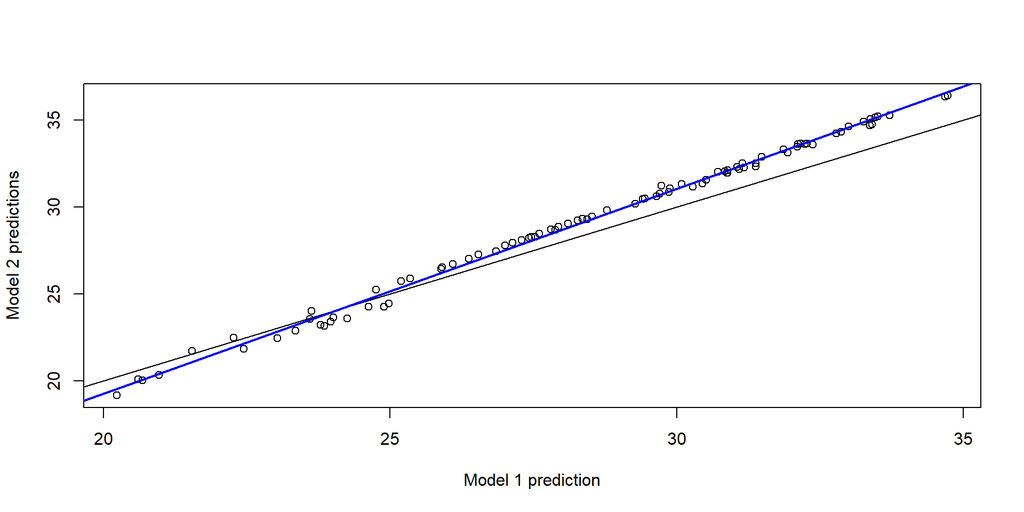

Seems like `Model 2` predicts smaller `mpg` when `Model 1` predicts small `mpg`, and higher when it predicts high `mpg`s.

**How much do the models agree?**

## A clever trick?

- Can’t use correlations - we want to check deviations from the line $y=x$, not $y = a+bx$!
- Two models can have correlation $1$ disagree completely (think $b = -1$.)

#### Possible solution

Plotting `c(x,y)` vs `c(y, x)` when `x`, `y` are the predictions of both models.

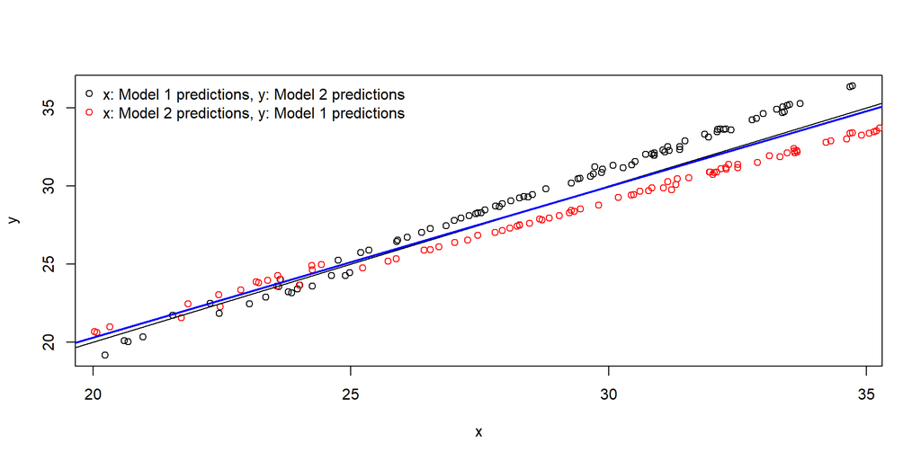

Calculating the correlation.

```r
x = predict(mod1, Auto[301:392,])
y = predict(mod2, Auto[301:392,])
cor(c(x,y), c(y, x))
```

```
[1] 0.9659919
```

Looks *ad hoc* and stupid? Sure!

**But it works!**

## The approach is sound

Define the *quadratic kappa* (Fleiss, 1973) as
$$\kappa_F(X,Y) = 1- \frac{E[(X-Y)^2]}{E[(X'-Y')^2]},$$
where $X',Y'$ are independent samples from their marginal distribution.

Then
$$\textrm{Cor}(X\frown Y, Y\frown X) = \kappa_F(X,Y),$$
where $X\frown Y$ and $Y\frown X$ are defined so that its sample estimator is `cor(c(x,y), c(y,x))`.

**You can estimate agreement using this bonkers method!**

## Inference

**Naïve approach.** Use standard OLS theory. This is an OLS, rigth?

**NO!** The observations are dependent in an insane way. OLS theory won’t help us.

- Instead, we do it the “SEM way”, using the $\Gamma$ matrix and so on.
- Exactly the same results can be obtained using the theory of $U$-statistics.

*But first, let’s look at the case of multiple raters (models)!*

# Multiple raters (or models)

## Agreement for multiple raters

Say we have $n$ models / raters. How do we measure agreement at **one** prediction?

### Sample variance

- $\textrm{var}(x_1, x_2, x_3, \ldots, x_n) = \frac{\overline{(x_i-\overline{x})^2}}{n}.$
- Measures the mean squared deviation from the “center”.
- Can be generalized to any loss function, with inferential accompanying theory. (Moss, 2024)

### Second approach

- Measure $(x_i - x_j)^2$ for all pairs $(i,j)$.
- These approaches are *equivalent*, but only for the square loss.

## Chance-correct measures of agreement

$$\kappa_F = 1 - \frac{D}{D_C},$$

- $D$ is expected disagreement under the true joint distribution of the ratings
- $D_C$ is the expected disagreement when all ratings are independently distributed from their marginal distributions.

**Variance form.**

- $D=E_P[\textrm{var}(X_1,X_2,\ldots, X_n),$
- $D_C = E_{\overline{P}}[\textrm{var}(X_1,X_2,\ldots, X_n),$ where $\overline{P}$ is the product measure of the marginals.

**Sum form.**

- $D = \sum_{i>j} E_P((X_i - X_j)^2)$
- $D = \sum_{i>j} E_P((X_i - X_j')^2),$ where $X_j$ is independently distributed of $X_i$ according to its marginal distribution.

## Example

Let’s fit four models.

```r
mod1 = lm("mpg ~ weight * cylinders + year", data = Auto[1:300,])
mod2 = lm("mpg ~ weight * cylinders * year", data = Auto[1:300,])
mod3 = lm("mpg ~ weight * cylinders ", data = Auto[1:300,])
mod4 = lm("mpg ~ weight + year", data = Auto[1:300,])
```

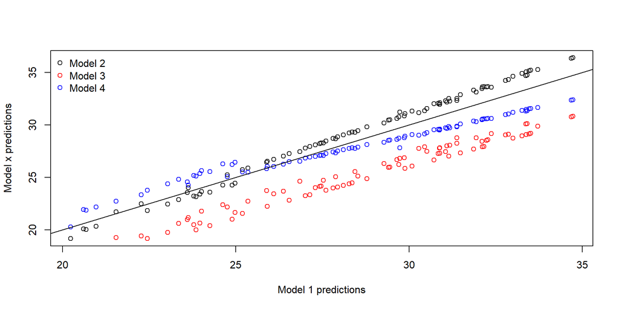

Pretty poor agreement between, e.g., model 1 and model 3 here!

## Population definition

Let $X$ be a random vector with mean $\mu$ and covariance $\Sigma$. The quadratic Fleiss’ kappa is then

$$\kappa_F = \frac{1^{T}\Sigma1-\textrm{tr}\Sigma-R\left(\overline{\mu^{2}}-\overline{\mu}^{2}\right)}{(R-1)\textrm{tr}\Sigma+(R-1)R\left(\overline{\mu^{2}}-\overline{\mu}^{2}\right)}.$$

- The standard estimator replace $\mu$ and $\Sigma$ with their (biased) sample counter-parts.
- **Inference?** A clear-cut example of standard asymptotic theory involving the fourth-order matrix $\Gamma$ in addition to $\mu$ and $\Sigma$.

## The correlation definition still holds!

Let’s construct some predictions for each model.

```r
x = predict(mod1, Auto[301:392,])
y = predict(mod2, Auto[301:392,])
z = predict(mod3, Auto[301:392,])
w = predict(mod4, Auto[301:392,])
```

I have dutifully implemented $\kappa_F$ in an `R` package.

```r
quadagree::fleiss(cbind(x,y,z,w))
```

```
[1] 0.7434601
```

But, behold!

```r
x1 = c(x,x,x,y,y,y,z,z,z,w,w,w)
x2 = c(y,z,w,x,z,w,x,y,w,x,y,z)
cor(x1, x2)
```

```
[1] 0.7434601
```

- A precise formulation of the relationship is tedious.
- We just need to make sure every pair `x`, `y` appears twice when calculating the correlation.

## Missing values

Assume ratings are missing at random. Let $S$ and $\hat{\mu}$ be calculated using pairwise available data.

From van Praag et al. (1985) we know that
$$\sqrt{n}(\textrm{vec}S - \textrm{vec}\Sigma) \stackrel{d}{\to} N(0, \Gamma \odot \Pi),$$

Moreover, we have
$$\sqrt{n}(\hat{\mu} - \mu) \stackrel{d}{\to} N(0, \Sigma + (P-I) \textrm{diag}(\Sigma)).$$
Here $P$ and $\Pi$ encodes the probability of missingness.

Everything else is the delta method. (Tedious!)

## Four models with missing values

We are not always able to obtaining all ratings, just a random subset.

```r
x, y, z, w # original predictions from 4 models
x_, y_, z_, w_ # predictions with missing data
```

```r
quadagree::fleissci(cbind(x_,y_,z_,w_))
```

```
Call: quadagree::fleissci(x = cbind(x_, y_, z_, w_))

95% confidence interval (n = 92).
    0.025     0.975
0.6639131 0.9127712

Sample estimates.
    kappa        sd
0.7883422 0.5975589
```

```r
quadagree::fleissci(cbind(x,y,z,w))
```

```
Call: quadagree::fleissci(x = cbind(x, y, z, w))

95% confidence interval (n = 92).
    0.025     0.975
0.6952208 0.7916994

Sample estimates.
    kappa        sd
0.7434601 0.2316650
```

## Existing methods are incorrect

- Existing methods use ad-hoc weighting methods introduced by Gwet (2020).
- These weighting methods are inconsistent, with asymptotically incorrect level, and do not use all available data.

```r
data <- cbind(x_,y_,z_,w_)
data <- data[rowSums(is.na(data)) <= 1, ]
#data <- round(data)
irrCAC::fleiss.kappa.raw(data, weights = "quadratic")$est
```

```
     coeff.name        pa        pe coeff.val coeff.se      conf.int p.value
1 Fleiss' Kappa 0.9804133 0.9187508   0.75893  0.04088 (0.676,0.842)       0
     w.name
1 quadratic
```

- Missing data are everywhere when measuring agreement.
- Consistency shoul be the *bare minimum* requirement for an estimator.

## Summary

1. Quadratic kappa is a correlation coefficient.
2. We can do inference with quadratic kappa with missing values.
3. Quadratic kappa with multiple raters can be interpreted in several ways.
4. `quadagree` implements the estimation and inference methods.
5. Current methods for handling missing data are **incorrect**.

Moreover,

1. These methods show great potential for motometry and other machine learning applications.
2. Preprint out in 1-3 months I think.
3. Will be submitted to Motometrika.